# Data Science - Module 8 PML - Project Assignment

# 2. Model fitting

## Model 1. Random Forest with principal components

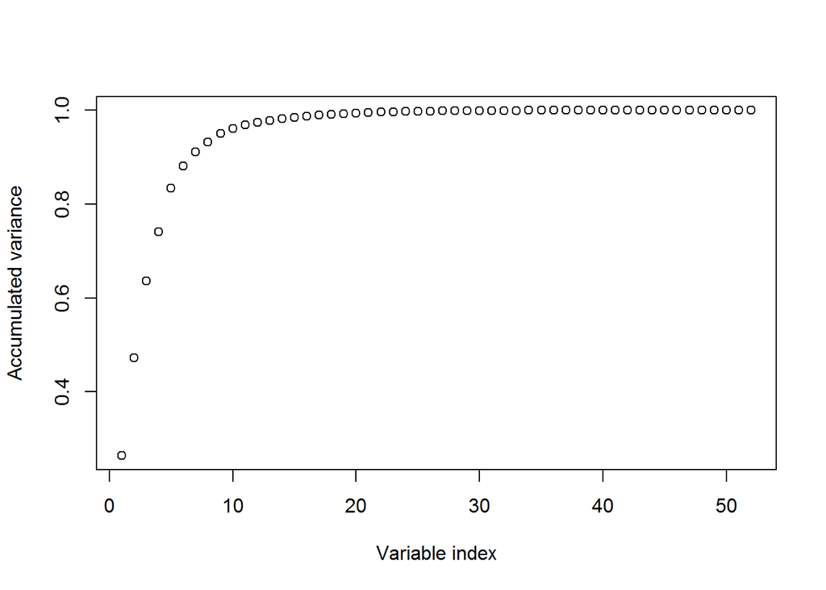

```r
# Datasets are preprocessed to perform a Principal Component Analysis
pcs<-prcomp(TR[,-53]); spcs<-summary(pcs)
# Let's plot the Cumulative proportion of variance of the Principal to see how many of them we need to consider 95% of the variance
plot(spcs$importance[3,],xlab='Variable index',ylab='Accumulated variance')
```

```r
# From the cumulative proportion we can see that the first nine PCs account for more than 95% of the variance. Let's pre-process
pr<-preProcess(TR[,-53],method="pca",pcaComp=9)
# now we transform the TR and VAL datasets into its principal components
TRpc<-predict(pr,TR[,-53])
VALpc<-predict(pr,VAL[,-53])
# Fit the model
RFmdl1<-randomForest(TR$classe~., data = TRpc)
```

## Model 2. RF with the complete dataset TR

With this model we predict on the VAl dataset

```r
RFmdl2<-randomForest(TR$classe~., data = TR)
```

```r
# ---------------------------------------------------------------------------------------
# Cross validation is established via train control
TC <- trainControl(method = "cv", number = 5, verboseIter=FALSE, preProcOptions="pca", allowParallel=TRUE)
RFmdl3<-train(classe ~., data = TR, trControl=TC, method = "rf")  # Random Forest
```

# 3. Prediction

Finally, we will use our models to predict the outcome for the VAL dataset and check the accuracy. let’s obtain the results first

```r
rmdl1<-predict(RFmdl1,VALpc); res<-as.data.frame(rmdl1)
res$rmdl2<-predict(RFmdl2,VAL)
res$rmdl3<-predict(RFmdl3,VAL)
print(res)
```

```
##    rmdl1 rmdl2 rmdl3
## 1      B     B     B
## 2      A     A     A
## 3      A     B     B
## 4      A     A     A
## 5      A     A     A
## 6      E     E     E
## 7      D     D     D
## 8      B     B     B
## 9      A     A     A
## 10     A     A     A
## 11     A     B     B
## 12     C     C     C
## 13     B     B     B
## 14     A     A     A
## 15     E     E     E
## 16     E     E     E
## 17     A     A     A
## 18     B     B     B
## 19     B     B     B
## 20     B     B     B
```

And now check the accuracy of the results

```r
a1<-1-sum(RFmdl1$confusion[,6])
a2<-1-sum(RFmdl2$confusion[,6])
a3<-max(RFmdl3$results$Accuracy)

print(c(a1,a2,a3))
```

```
## [1] 0.8142247 0.9845820 0.9949545
```

# 4. Conclusions

The first model gives different results than the other two. Based on the accuracy of the models, we would select the last model over the other two

# 5. References

1. “Human activity recognition” [link](http://groupware.les.inf.puc-rio.br/har)
2. “Qualitative activity recognition of weight lifting exercises” Velloso, Bulling, Gellersen, Ugulino, Fuks. 2013 [link](http://groupware.les.inf.puc-rio.br/work.jsf?p1=11201)